# Yogurt Flavor Selection

Chenxi Tao

2/2/2020

## Set up Environment and Load Datasets

```r
# Set up environments
library(tidyverse)
library(formattable)
library(lubridate)
library(stringr)
dir = "~/Desktop/Courses/GBA424/Assignments/Project 2"
setwd(dir)

################################
#          SQL CODE            #
################################

# SQL command to extract `storeItemSales.csv` and `itemAttributes.csv`
# select * from storeItemSales
# select * from itemAttributes

# Load datasets
# For question 1, 2
itemsAttributes = read.csv('itemsAttributes.csv')
storeItemSales = read.csv('storeItemSales.csv')
# For question 3, 4
survResponses = read.csv('survResponses.csv')
survQuestions = read.csv('survQuestions.csv')
```

## Question 1: Percentage of sales of existing flavors in the Greek yogurt category

We chose sales data from all the stores because it is the most representative data for the whole population.

```r
# Merge sales data table with item attributes data table
salesData = merge(itemsAttributes, storeItemSales, right_on='Item.Num')
```

For Greek yogurt, we only include six flavors mentioned in the case as currently existing flavors.

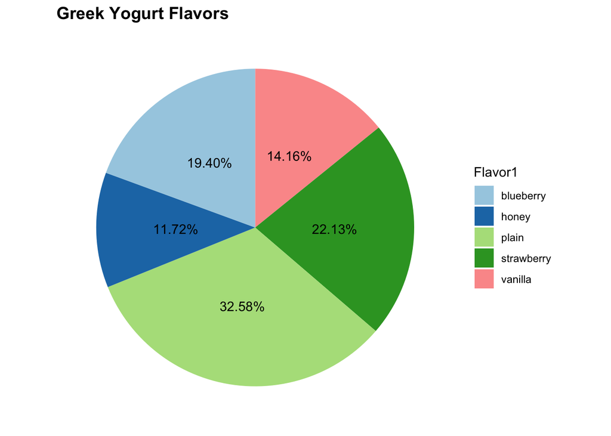

```r
################################
#      OUTPUT FOR SLIDE 2      #
################################

existingFlavor=c('plain','strawberry','blueberry','honey','vanilla','peach')

# calculate the percentage of sales
greekYogurt=
  salesData %>%
  filter(Class=='GREEK', Flavor1 %in% existingFlavor) %>%   # Where
  group_by(Flavor1) %>%   # Group by
  summarize(total_sales=sum(Sales)) %>% # Aggregation
  mutate(Percentage=percent(total_sales/sum(total_sales))) %>% # Calculate percentage in a new column
  arrange(desc(Percentage)) # Order by

# PLOT PIE CHART
library(ggplot2)

# Create a bar plot
bp<- ggplot(greekYogurt, aes(x="", y=Percentage, fill=Flavor1))+geom_bar(width = 1, stat = "identity")

# Create a pie chart with title
pie <- bp + coord_polar("y", start=0)+ggtitle('Greek Yogurt Flavors')

# Define the theme with blank grids
blank_theme <- theme_minimal()+
  theme(
  axis.title.x = element_blank(),
  axis.title.y = element_blank(),
  panel.border = element_blank(),
  panel.grid=element_blank(),
  axis.ticks = element_blank(),
  plot.title=element_text(size=14, face="bold")
  )

# Add labels to the pie chart
pie <- pie + scale_fill_brewer(palette="Paired")+theme_minimal()+blank_theme+theme(axis.text = element_blank(),axis.ticks = element_blank(),panel.grid  = element_blank())+geom_text(aes(label=Percentage),position = position_stack(vjust = 0.5))
pie
```

## Question 2: Percentage of sales of existing flavors outside the Greek yogurt category

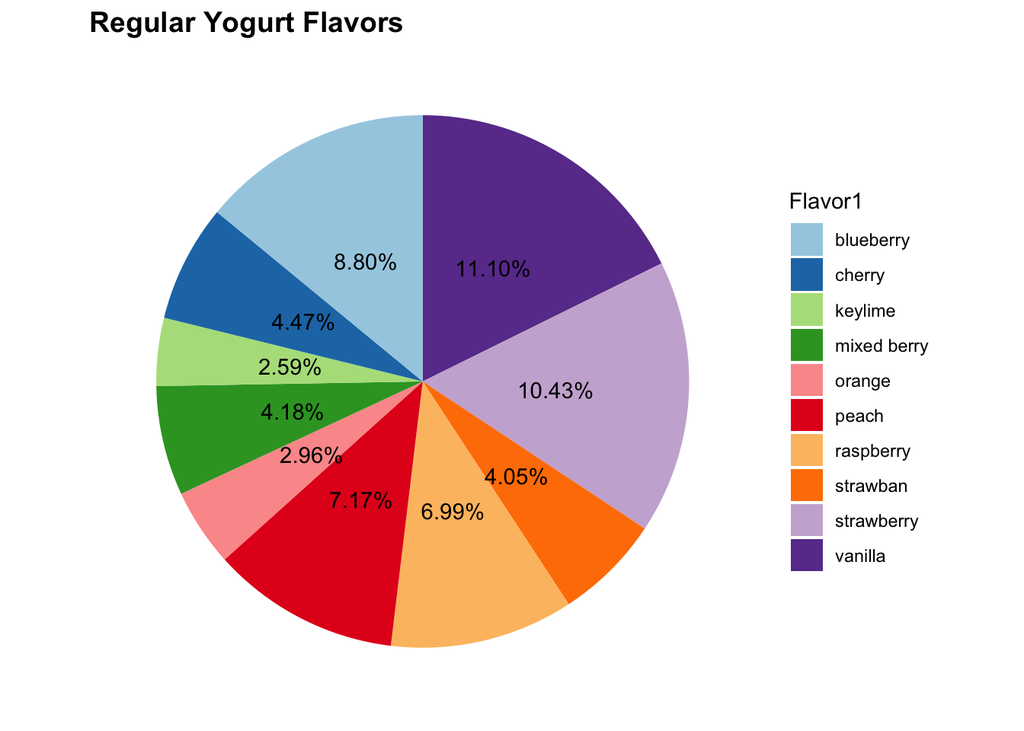

```r
################################
#      OUTPUT FOR SLIDE 3      #
################################

# Calculate the percentage of sales
regular =
  salesData %>%
  filter(Class=='REGULAR') %>%   # where
  group_by(Flavor1) %>%   # group by
  summarize(total_sales=sum(Sales)) %>% #aggregation
  mutate(Percentage=percent(total_sales/sum(total_sales))) %>% #create a new column
  arrange(desc(Percentage)) # order by

# Change the category of flavors outside the top10 popular flavors as "Others"
levels(regular$Flavor1) <- c(levels(regular$Flavor1), "Others")
regular[11:82,1] = "Others"

# Calculate the percentage of sales
Regular_Yogurt =
    regular %>%
        group_by(Flavor1) %>%# group by %>% #aggregation
        summarize(Percentage=sum(Percentage)) %>%
        arrange(desc(Percentage))

# PLOT PIE CHART

# create a bar plot
bp2<- ggplot(Regular_Yogurt, aes(x="", y=Percentage, fill=Flavor1))+geom_bar(width = 1, stat = "identity")

# create a pie chart with title
pie2 <- bp2 + coord_polar("y", start=0)+ggtitle('Regular Yogurt Flavors')

# add labels to the pie chart
pie2 <- pie2 + scale_fill_brewer(palette="Paired")+theme_minimal()+blank_theme+theme(axis.text = element_blank(),axis.ticks = element_blank(),panel.grid  = element_blank())+geom_text(aes(label=Percentage),position = position_stack(vjust = 0.5))
pie2
```

## Question 3: Describe survey respondents’ preferences for Greek yogurt flavors

Before conducting analysis, first we needed to do some data cleaning and processing.

```r
# Change column names of `survResponses` in `Question 12` to flavors' name

# Extract flavor names from `survQuestions`. Before running this line, we identify an error in survQuestions.csv's Q3_8 column and fix it with Excel.
flavorNames = sapply(survQuestions[1, ], function (x) {substring(x, 105, nchar(as.character(x), type="chars") - 6)})

# Change column names of `survResponses`
names(survResponses)[c(15:37)] <- flavorNames[c(15:37)]
```

We removed unreliable survey samples which: - are incomplete (V10 == 0), - skipped Question 12 entirely, and - take longer than 30 minutes to complete.

```r
# Remove incomplete answers
sum(survResponses$V10 == 0) # 129 incomplete answers
```

```
## [1] 129
```

```r
survResponses <- survResponses[survResponses$V10 != 0, ]

# Remove samples which skipped Q12 entirely
emptyQ12 <- apply(survResponses[, c(15:37)], 1, function(x) {all(is.na(x))})
sum(emptyQ12) # 19 people skipped Q12 entirely
```

```
## [1] 19
```

```r
survResponses <- survResponses[!emptyQ12, ]

# Calculate time taken to answer survey
survResponses$V8 <- ymd_hms(survResponses$V8)
survResponses$V9 <- ymd_hms(survResponses$V9)
survResponses$timeElapsed <- as.numeric(difftime(survResponses$V9, survResponses$V8, units="mins"))
# Remove answers took more than 30 minutes to complete
longAnswer <- survResponses$timeElapsed > 30
sum(longAnswer) # 25 unreliable answers
```

```
## [1] 25
```

```r
survResponses <- survResponses[!longAnswer, ]

# After remove unreliable responses, there are 579 samples left.
dim(survResponses)
```

```
## [1] 579  38
```

After removing unreliable samples, we assumed that NA values in Question 12 columns mean `Never` and replaced these NA values with `2`.

```r
# Replace missing values with value `2`
flavors <- survResponses[, c(15: 37)]
flavors[is.na(flavors)] <- 2
```

After data cleaning, we exported our data and use Tableau to create visualization for the our 4th slides. The code below will create similar bar charts.

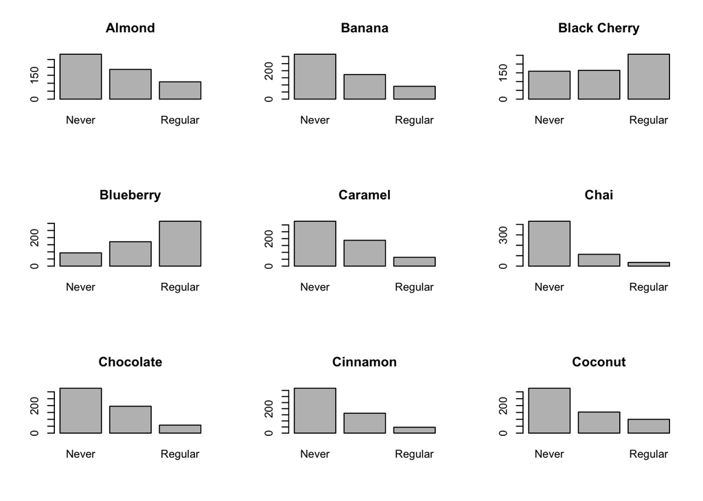

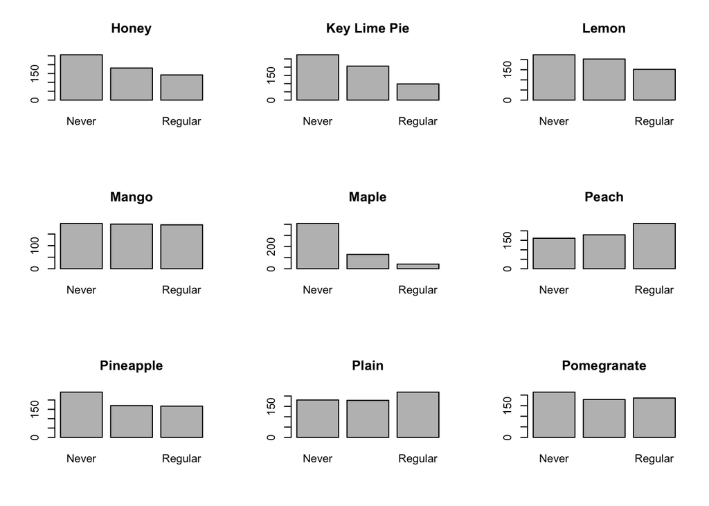

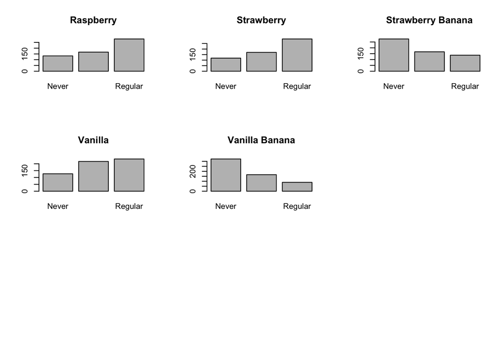

```r
################################
#      OUTPUT FOR SLIDE 4      #
################################

# Export data for visualization in Tableau
flavorData <- ifelse(flavors==0, "Regular", ifelse(flavors==2, "Never", "Occasionally"))
write.csv(flavorData,'flavorData')

# Create bar chart to understand preference
par(mfrow=c(3, 3));
for (i in 1:length(colnames(flavorData))) {
    x = flavorData[,i]
    plot(factor(x),main=colnames(flavorData)[i])
}
```

## Question 4: Predict the best set of next flavors to add to achieve the highest reach using survey data

Before conducting TURF analysis, we will encode the data as following: - Regularly: 4 - Occasionally: 1 - Never: 0

Originally, “Regularly” is encoded as 0, “Occasionally” as 1, and “Never” as 2.

```r
# Encode data
flavorPurchase <- ifelse(flavors==0, 4, ifelse(flavors==2, 0, 1))
```

The code below will be used to do TURF Analysis. The codes are taken from `WegmansSurveyCase.Rmd` file provided by Prof. Lovett. We created a new function `measFreq` to measure total frequency.

```r
#measReach: measures reach given set of options and data
measReach = function(data){ #measures reach given expected data
  if(is.null(dim(data))){ #if data is a vector
    ret = sum(data>1,na.rm=TRUE)/length(data)
  } else if(ncol(data)==1){ #if data has only one column
    ret = sum(data>1,na.rm=TRUE)/length(data)
  }
  else { #if data has multiple columns
    ret = sum(apply(data>1,1,any),na.rm=TRUE)/nrow(data) #any: is at least one of the values true?
  }
}

#measFreq: measures frequency given set of options and data
measFreq = function(data){
    if(is.null(dim(data))){ #if data is a vector
        ret = sum(data,na.rm=TRUE)
    } else if(ncol(data)==1){ #if data has only one column
        ret = sum(data,na.rm=TRUE)
    }
    else { #if data has multiple columns
        ret = sum(apply(data>1,1,sum),na.rm=TRUE)
    }
    ret
}

#evalNext: evaluates the next set, nextSet using measure given existing set in data
evalNext = function(nextSet,set,data,measure=measReach){ #evaluates each option in a set for total reach
  vals = numeric(length(nextSet)) #set up storage for return value
  for(k in 1:length(nextSet)){ #loop over the options in nextSet
    if(length(set)==0){         #if no existing options
      vals[k] = measure(data[,nextSet[k]])
    } else {                    #if existing options
      vals[k] = measure(data[,c(set,nextSet[k])])
    }
  }
  vals
}

#evalFull: creates optimal full evaluation starting from origSet and considering remaining options fullSet
evalFull = function(fullSet,data,origSet=numeric(0),measure=measReach){
  #evaluates full set of cases picking optimal at each stage, returns a TURF object
  curSet = origSet; #the current set of included options
  remSet = fullSet[!(fullSet%in%origSet)]; #the remaining set of options to consider
  K = length(remSet)
  optVals = numeric(K); #create storage for the optimal values (optVals)
  ordSet = numeric(K); #create storage for ordered set
  for(i in 1:K){          #loop over the remaining set consider
    tmpVals = evalNext(remSet,curSet,data,measure); #calculate vector of next evaluations
    k = which.max(tmpVals) #pick the option that gives max measure, note will pick first case if a tie!
    optVals[i] = tmpVals[k] #add optimal value
    ordSet[i] = remSet[k]   #add index of option that creates optimal value
    curSet = c(curSet,ordSet[i]); #add optimal next option to current set
    remSet = remSet[-k];          #delete optimal next option from remaining set
  }
  #creaets a "TURF object" containing ordSet, optVals, origSet, origVal, measure, and pnames
  turf = list(ordSet=ordSet,optVals=optVals,origSet=origSet,origVal=measure(data[,origSet]),measure=measure,pnames=colnames(data))
  class(turf)="TURF" #makes the list into a TURF object so that can call plot.TURF
  turf  #return turf
}

#creates ggplot barplot for a turf object
plot.TURF=function(turf,...){
  if(class(turf)!="TURF"){
    cat("Object not a turf.") #concatenate and print
  } else {
    df = with(turf,data.frame(vals = c(origVal,optVals),
                              titles=paste(0:length(ordSet),
                                           c("Original",pnames[ordSet]),sep=":")))
    #with(turf,barplot(c(origVal,optVals),names.arg=c("Original",pnames[ordSet])))
    dodge = position_dodge(width=.75); ##to form constant dimensions positioning for all geom's
    df$titles <- factor(df$titles, levels=df$titles)
    gp = ggplot(df,aes(y=vals,x=titles))
    gp + geom_bar(position=dodge,stat="identity",col=1,fill="lightblue",width=.75) + labs(title="Turf Analysis", x="Flavors") + scale_x_discrete(labels = function(x) str_wrap(x, width = 10))
  }
}
```

We will measure Reach and Frequency with and without the original set.

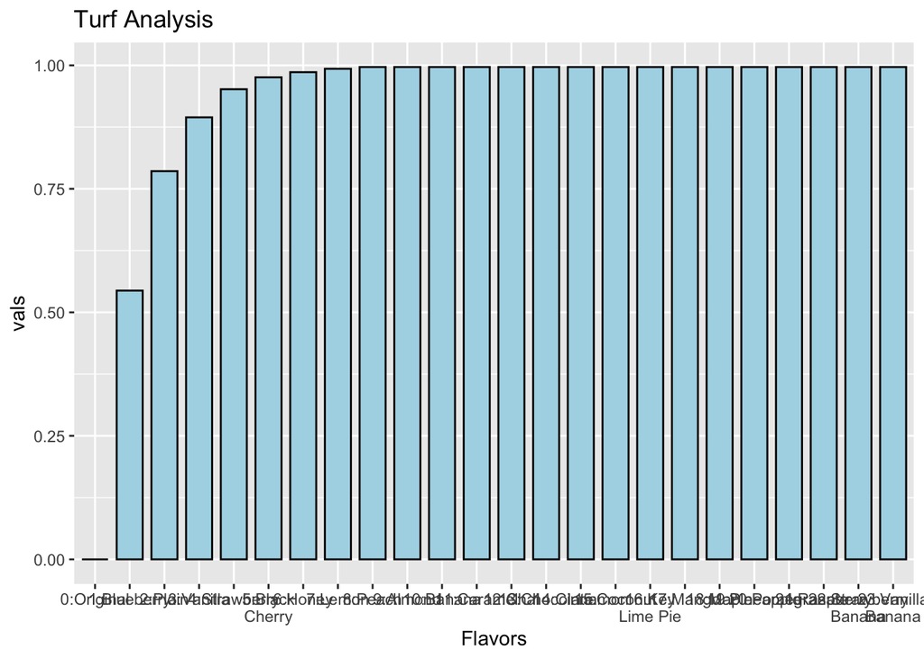

```r
################################
#      OUTPUT FOR SLIDE 5      #
################################

originSet <- which(colnames(flavorPurchase) %in% c("Blueberry", "Honey", "Peach",
                                                   "Plain", "Strawberry", "Vanilla"))
fullSet <- 1:length(colnames(flavorPurchase))

# Reach with no original set
turf.1 = evalFull(fullSet, flavorPurchase, measure=measReach)
plot.TURF(turf.1)
```

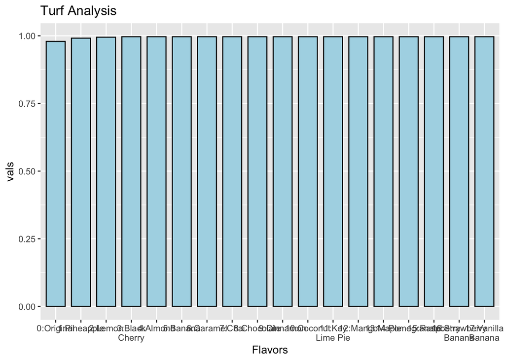

```r
# Reach with the original set
turf.2 = evalFull(fullSet, flavorPurchase, originSet, measure=measReach)
plot.TURF(turf.2)
```

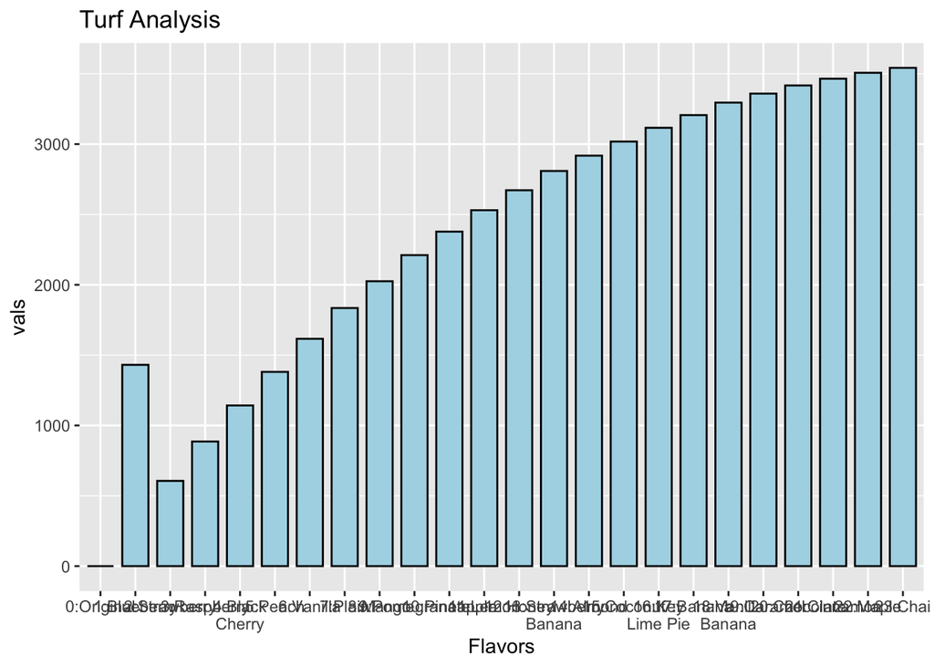

```r
# Frequency with no original set
turf.3 = evalFull(fullSet, flavorPurchase, measure=measFreq)
plot.TURF(turf.3)
```

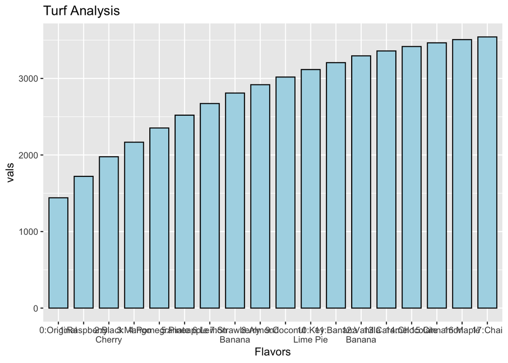

```r
# Frequency with the original set
turf.4 = evalFull(fullSet, flavorPurchase, originSet, measure=measFreq)
plot.TURF(turf.4)
```